# R Notebook

Kaz Shakir

```r
# setup environment
#
library(magrittr)
library(rpart)
library(dplyr)
library(ggplot2)
library(scales)
# load and clean the initial data
#
# load the csv file into a data.frame
# convert the Date,Started field into a Date type
# and make the County names all caps
#
icData <- read.csv(file = '20181009.csv')
icData$Date.Started <- as.Date(as.character(icData$Date.Started), format = "%m/%d/%Y")
icData$County <- toupper(icData$County)
# create a variable for the estimatedAge, and another
# for the jobTerm (the number of years person has been in the job)
#
icData$estimatedAge <- as.integer(format(Sys.Date(), "%Y")) - icData$Year.of.Birth
icData$jobTerm <- as.integer(format(Sys.Date(), "%Y")) - as.integer(format(icData$Date.Started, "%Y"))
# create a subset of the data that only includes
# elected officials, and full-time employees
#
modelSubset <-
  subset(icData,
         ((icData$Employment.Status == 'Elected' ||
            icData$Employment.Status == 'Full Time')) &
           (icData$Annual.Salary >= 12000)) %>%
  droplevels()
# calculate some descriptive statistics by Job Category
#
a1 <- modelSubset %>%
  group_by(EEO.Job.Cat.Desc) %>%
  summarise(low = min(Annual.Salary), high = max(Annual.Salary), avg = mean(Annual.Salary),
            stdDev = sd(Annual.Salary), cv = sd(Annual.Salary) / mean(Annual.Salary)) %>%
  arrange(avg)
```

### Salary statistics by Job Description category:

```r
print(a1)
```

| EEO.Job.Cat.Desc | low | high | avg | stdDev | cv |
| --- | --- | --- | --- | --- | --- |
| Para-Professional | 12232.44 | 55314.29 | 31700.39 | 9851.973 | 0.3107840 |
| Service Maintenance | 12262.85 | 72604.66 | 38027.32 | 8058.876 | 0.2119233 |
| Administrative Support | 12055.68 | 95400.00 | 40407.14 | 11831.612 | 0.2928100 |
| Skilled Craft Workers | 27040.00 | 87949.05 | 49871.93 | 8481.572 | 0.1700671 |
| Protective Service Workers | 13636.48 | 91450.06 | 54385.71 | 10007.455 | 0.1840089 |
| Professionals | 12546.56 | 188190.00 | 62213.78 | 21438.453 | 0.3445933 |
| Technicians | 15224.60 | 95441.36 | 63592.71 | 12036.964 | 0.1892821 |
| Elected Officials | 15000.00 | 180000.00 | 68862.66 | 73537.559 | 1.0678872 |
| Officials and Administrators | 15000.00 | 319200.00 | 87919.78 | 36743.891 | 0.4179252 |

- Observations:
- The Elected Officials seem to have a very wide dispersion of salaries, as demonstrated by the cv ratio (whcih is the standard deviation divided by the average).
- The Officials and Administrators categry also seems to have a wide dispersion of values, ranging from a low of $15,000 to a high of $319,200.
- The “Officials and Administrators”, “Professionals”, and “Elected Official” categories all seem to have particularly high paid positions

### A box and whisker chart of the distribution of salaries by job description category, excluding

### the Elected Officials, Professionals, and Officials and Administrators

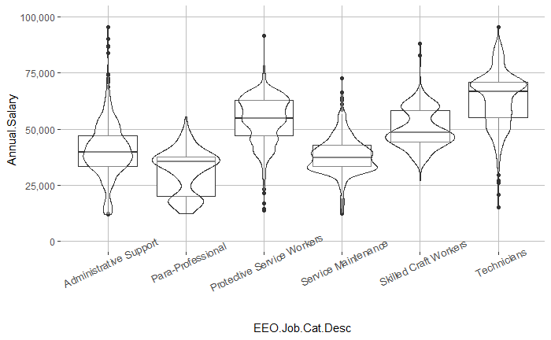

```r
ggplot(data = modelSubset[(modelSubset$EEO.Job.Cat.Desc != 'Elected Officials') &
                            (modelSubset$EEO.Job.Cat.Desc != 'Officials and Administrators') &
                            (modelSubset$EEO.Job.Cat.Desc != 'Professionals'),],
       aes(x = EEO.Job.Cat.Desc, y = Annual.Salary, ymax = 100000, ymin = 0)) +
  geom_boxplot() +
  geom_violin(alpha = 0.4) +
  scale_y_continuous(labels = comma) +
  theme(axis.text.x = element_text(size = 10, angle = 25),
        panel.background = element_rect(fill = FALSE),
        panel.grid.major = element_line(color = 'gray'))
```

```r
NA
```

- Observations:
- Based on the levels of the various boxes, it appears that there are two prevalent groups
  - First, the Support group that includes: Administrative Support, Para-Professionals, and Service Maintenance
  - Second, the Skilled Labor group that includes: Protective Service Workers, Skilled Craft Workers, and Technicians

### A box and whisker chart for the Elected Officials, Officials and Administrators, and Professionals

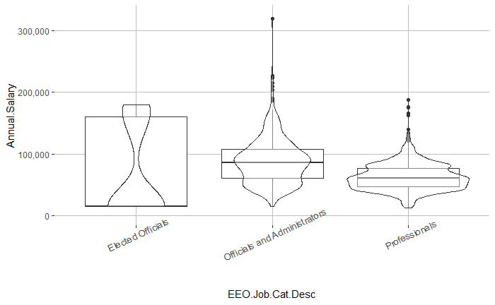

```r
ggplot(data = modelSubset[(modelSubset$EEO.Job.Cat.Desc == 'Elected Officials') |
                            (modelSubset$EEO.Job.Cat.Desc == 'Officials and Administrators') |
                            (modelSubset$EEO.Job.Cat.Desc == 'Professionals'),],
       aes(x = EEO.Job.Cat.Desc, y = Annual.Salary, ymax = 325000, ymin = 0)) +
  geom_boxplot() +
  geom_violin(alpha = 0.4) +
  scale_y_continuous(labels = comma) +
  theme(axis.text.x = element_text(size = 10, angle = 25),
        panel.background = element_rect(fill = FALSE),
        panel.grid.major = element_line(color = 'gray'))
```

```r
NA
```

The Officials and Administrators and Professionals categories could be grouped into a single category called Management - they seem to be similar enough.

Elected officials, however, seem to have a very odd profile: a wide range, but the median is all the way to the bottom.

### An ordered scatter plot of the Elcted Officials category

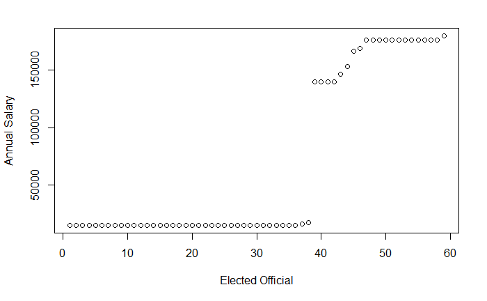

```r
plot(sort(modelSubset$Annual.Salary[modelSubset$EEO.Job.Cat.Desc == 'Elected Officials']),
     ylab = "Annual Salary", xlab = "Elected Official")
```

Now, it seems clear that the elected officials seem to group into three distinct categories, with most of them below $25k and then a small group around $130 or $140, and a thrid group at $170 or $180.

So, it seems that there are three distinct groups: + Support + Skilled Labor + Management

```r
# add a column to the dataframe to represent the three major groups and Elected Officials
# as the fourth group.
#
modelSubset$group <-
  as.factor(
    apply(modelSubset, MARGIN = 1, FUN = function(x) {
      if (x["EEO.Job.Cat.Desc"] %in%
          c('Administrative Support', 'Para-Professional', 'Service Maintenance'))
        {return ('Support')}
      if (x["EEO.Job.Cat.Desc"] %in%
          c('Protective Service Workers', 'Skilled Craft Workers', 'Technicians'))
        {return ('Skilled Labor')}
      if (x["EEO.Job.Cat.Desc"] %in%
          c('Officials and Administrators', 'Professionals'))
        {return ('Management')}
      if (x["EEO.Job.Cat.Desc"] == 'Elected Officials')
        {return ('Elected')}
    })
  )
```

### Draw denisty of the distribution for each of the four categories

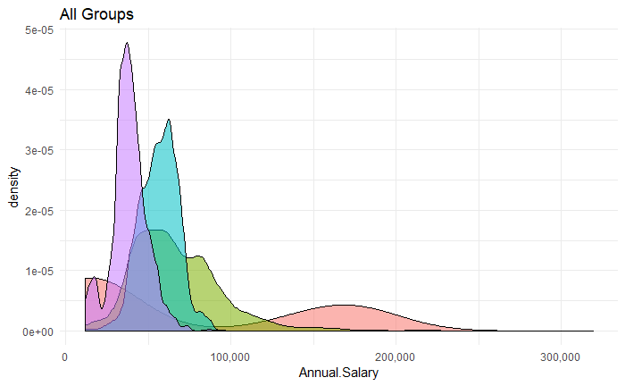

```r
ggplot(modelSubset,
       aes(Annual.Salary, group = group, fill = group, alpha = 0.25)) +
  geom_density()+
  scale_x_continuous(label = comma) +
  ggtitle("All Groups") +
  theme_minimal() +
  theme(legend.position = "none")
```

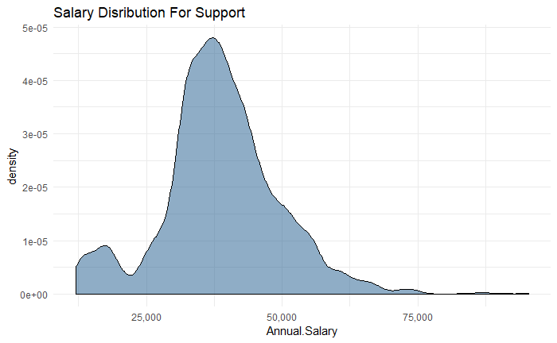

```r
ggplot(modelSubset[modelSubset$group == 'Support',],
       aes(Annual.Salary, fill = 4, alpha = 0.25)) +
  geom_density() +
  scale_x_continuous(label = comma) +
  ggtitle("Salary Disribution For Support") +
  theme_minimal() +
  theme(legend.position = "none")
```

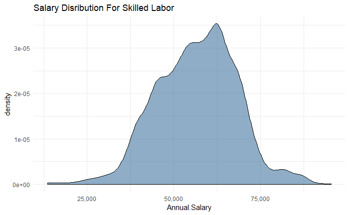

```r
ggplot(modelSubset[modelSubset$group == 'Skilled Labor',],
       aes(Annual.Salary, fill = 4, alpha = 0.25)) +
  geom_density() +
  scale_x_continuous(label = comma) +
  ggtitle("Salary Disribution For Skilled Labor") +
  theme_minimal() +
  theme(legend.position = "none")
```

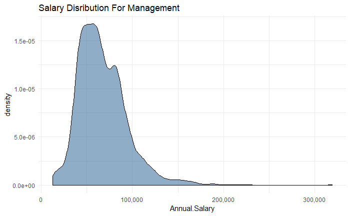

```r
ggplot(modelSubset[modelSubset$group == 'Management',],
       aes(Annual.Salary, fill = 4, alpha = 0.25)) +
  geom_density() +
  scale_x_continuous(label = comma) +
  ggtitle("Salary Disribution For Management") +
  theme_minimal() +
  theme(legend.position = "none")
```

Each of the groups seems to be normally distributed with some outliers. The Support group seems to have a small set of jobs in a low paid category; and the other groups seem to have a few on the very high end of the scale.

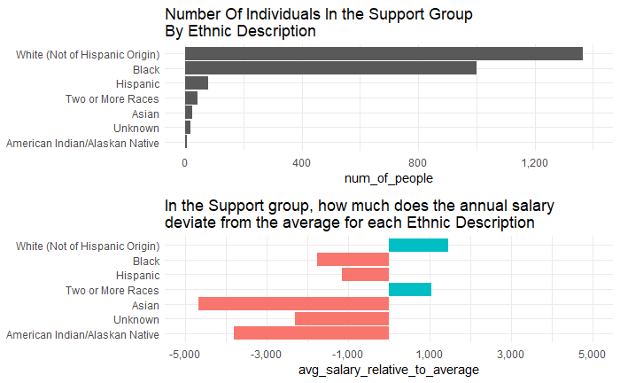

```r
# build a function to create summary statistics for evaluation
#
summaryStats <- function(df, grp) {
  # calculate some summary statistics for the grp group by Ethnic code
  # first, determine the number employed in each ethnic group
  # second, determine the average salary by ethnic group
  #
  result <-
    df[df$group == grp,] %>%
    group_by(Ethnic.Code.Description) %>%
    summarise(num_of_people = n(), avg_salary = mean(Annual.Salary)) %>%
    arrange(num_of_people)

  # determine the overall average salary for the grp group
  # and then calculate the amount each ethnic group is either
  # above or below that average
  #
  AvgSal <- mean(df$Annual.Salary[df$group == grp])
  result$avg_salary_relative_to_average <-
    result$avg_salary - AvgSal

  return(result)
}
# build a function to create two bar charts for the summarize results
# that were produced by the summaryStats function
#
producePlots <- function(smry, grp, lmts1, brks1, lmts2, brks2) {
  # plot a bar chart of the number of people employed in each ethnic category
  # in the grp group, and a second graph showing the average salary
  # by each ethnic group relative to the average for the grp group
  #
  p1 <-
    ggplot(smry,
         aes(reorder(Ethnic.Code.Description, num_of_people), num_of_people)) +
    scale_y_continuous(limits = lmts1,
                       breaks = brks1,
                       labels = comma) +
    geom_col() + labs(x = NULL) + coord_flip() +
    ggtitle(paste0("Number Of Individuals In the ", grp,
                   " Group \nBy Ethnic Description")) +
    theme_minimal()

  p2 <-
    ggplot(smry,
         aes(reorder(Ethnic.Code.Description, num_of_people), avg_salary_relative_to_average,
             fill = as.factor(sign(avg_salary_relative_to_average)))) +
    scale_y_continuous(limits = lmts2,
                       breaks = brks2,
                       labels = comma) +
    geom_col() + labs(x = NULL) + coord_flip() +
    ggtitle(paste0("In the ", grp, " group, how much does the annual salary \n",
                   "deviate from the average for each Ethnic Description")) +
    theme_minimal() +
    theme(legend.position = "none")

  return(list(p1 = p1, p2 = p2))

}
supportSummary <- summaryStats(modelSubset, 'Support')
supportPlots <- producePlots(supportSummary, 'Support',
                             lmts1 = c(0,1400), brks1 = seq(0, 1400, 400),
                             lmts2 = c(-5000,5000), brks2 = seq(-5000,5000,2000))
grid.arrange(supportPlots$p1, supportPlots$p2, ncol = 1)
```

Do the same for the skilled labor group

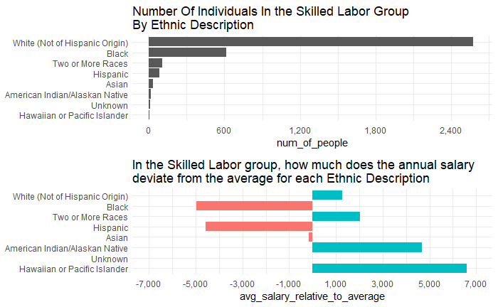

```r
skilledSummary <- summaryStats(modelSubset, 'Skilled Labor')
skilledPlots <- producePlots(skilledSummary, 'Skilled Labor',
                             lmts1 = c(0,2600), brks1 = seq(0, 2600, 600),
                             lmts2 = c(-7000,7000), brks2 = seq(-7000,7000,2000))
grid.arrange(skilledPlots$p1, skilledPlots$p2, ncol = 1)
```

Do the same calcs for the Management group

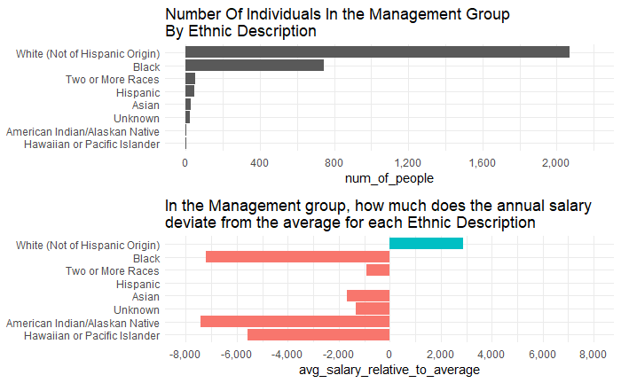

```r
managementSummary <- summaryStats(modelSubset, 'Management')
managementPlots <- producePlots(managementSummary, 'Management',
                             lmts1 = c(0,2200), brks1 = seq(0, 2200, 400),
                             lmts2 = c(-8000,8000), brks2 = seq(-8000,8000,2000))
grid.arrange(managementPlots$p1, managementPlots$p2, ncol = 1)
```